# Import, Inspect, Clean and Explore a Dataset

Your name goes here

2021-09-03

```r
knitr::opts_chunk$set(
  message = FALSE,
  warning = FALSE,
  tidy=FALSE,     # display code as typed
  size="small")   # slightly smaller font for code
options(digits = 3)

# default figure size
knitr::opts_chunk$set(
  fig.width=2.5,
  fig.height=2.5,
  fig.align = "center"
)
```

# Task 1: London Bike Rentals and London weather

The dataset we will be working with contains the number of daily bike rentals in London as well as some temperature data for each day in London. The data for daily bike rentals comes from [TfL](https://data.london.gov.uk/download/number-bicycle-hires/ac29363e-e0cb-47cc-a97a-e216d900a6b0/tfl-daily-cycle-hires.xlsx)

## Import and inspect the datafile

The first step is to import the data into R. We will use either `readr::read_csv()` or `vroom::vroom()`– I prefer the latter as it is a lot faster. Once you import any datafile, make sure the first thing you do is use `janitor::clean_names()`

```r
bike_weather <- vroom(here::here("data","london_bikes.csv")) %>%
  janitor::clean_names() %>%
  mutate(month = lubridate::month(day, label = TRUE),
         weekday = lubridate::wday(day, label=TRUE)
  )
```

Having imported the datafame, we need to inspect it to see what kind of variables it contains, whether there are any missing values, etc.

```r
skim(bike_weather)
```

Data summary

| Name | bike_weather |
| --- | --- |
| Number of rows | 3959 |
| Number of columns | 25 |
| _______________________ |  |
| Column type frequency: |  |
| character | 1 |
| factor | 2 |
| numeric | 21 |
| POSIXct | 1 |
| ________________________ |  |
| Group variables | None |

**Variable type: character**

| skim_variable | n_missing | complete_rate | min | max | empty | n_unique | whitespace |
| --- | --- | --- | --- | --- | --- | --- | --- |
| prcp_attributes | 2 | 1 | 1 | 1 | 0 | 5 | 0 |

**Variable type: factor**

| skim_variable | n_missing | complete_rate | ordered | n_unique | top_counts |
| --- | --- | --- | --- | --- | --- |
| month | 0 | 1 | TRUE | 12 | Jan: 341, Mar: 341, May: 341, Aug: 341 |
| weekday | 0 | 1 | TRUE | 7 | Sun: 566, Mon: 566, Fri: 566, Sat: 566 |

**Variable type: numeric**

| skim_variable | n_missing | complete_rate | mean | sd | p0 | p25 | p50 | p75 | p100 | hist |
| --- | --- | --- | --- | --- | --- | --- | --- | --- | --- | --- |
| bikes_hired | 0 | 1.00 | 25887.76 | 9564.84 | 2764.0 | 18985.00 | 25730.0 | 32711.5 | 73094.0 | ▃▇▅▁▁ |
| yday | 2 | 1.00 | 183.24 | 106.20 | 1.0 | 91.00 | 183.0 | 276.0 | 366.0 | ▇▇▇▇▇ |
| temp | 2 | 1.00 | 11.60 | 5.49 | -4.1 | 7.50 | 11.4 | 15.8 | 28.6 | ▁▆▇▅▁ |
| dewp | 2 | 1.00 | 7.11 | 4.68 | -9.2 | 3.80 | 7.3 | 10.7 | 18.8 | ▁▃▇▇▂ |
| slp | 3136 | 0.21 | 1015.56 | 9.78 | 978.2 | 1009.85 | 1015.7 | 1021.8 | 1041.4 | ▁▂▇▇▂ |
| stp | 3137 | 0.21 | 106.20 | 285.69 | 0.1 | 9.22 | 14.6 | 22.0 | 999.7 | ▇▁▁▁▁ |
| visib | 27 | 0.99 | 10.88 | 3.16 | 0.3 | 9.70 | 10.5 | 11.4 | 27.7 | ▁▇▃▁▁ |
| wdsp | 2 | 1.00 | 4.07 | 1.70 | 0.8 | 2.80 | 3.8 | 5.0 | 12.2 | ▅▇▃▁▁ |
| mxspd | 2 | 1.00 | 6.86 | 2.52 | 1.5 | 5.10 | 6.7 | 8.2 | 21.0 | ▅▇▂▁▁ |
| gust | 2633 | 0.33 | 13.21 | 3.31 | 7.2 | 10.80 | 12.4 | 14.9 | 28.3 | ▆▇▃▁▁ |
| max_temp | 2 | 1.00 | 15.72 | 6.49 | -1.2 | 11.00 | 15.2 | 20.5 | 37.2 | ▂▇▇▃▁ |
| min_temp | 2 | 1.00 | 7.52 | 5.09 | -9.4 | 3.90 | 7.7 | 11.7 | 21.7 | ▁▅▇▆▁ |
| prcp | 2 | 1.00 | 1.67 | 3.68 | 0.0 | 0.00 | 0.0 | 1.5 | 48.0 | ▇▁▁▁▁ |
| i_fog | 2 | 1.00 | 0.68 | 0.47 | 0.0 | 0.00 | 1.0 | 1.0 | 1.0 | ▃▁▁▁▇ |
| i_rain_drizzle | 2 | 1.00 | 0.06 | 0.24 | 0.0 | 0.00 | 0.0 | 0.0 | 1.0 | ▇▁▁▁▁ |
| i_snow_ice | 7 | 1.00 | 0.00 | 0.06 | 0.0 | 0.00 | 0.0 | 0.0 | 1.0 | ▇▁▁▁▁ |
| i_hail | 7 | 1.00 | 0.02 | 0.13 | 0.0 | 0.00 | 0.0 | 0.0 | 1.0 | ▇▁▁▁▁ |
| i_thunder | 12 | 1.00 | 0.00 | 0.03 | 0.0 | 0.00 | 0.0 | 0.0 | 1.0 | ▇▁▁▁▁ |
| ea | 2 | 1.00 | 1.05 | 0.33 | 0.3 | 0.80 | 1.0 | 1.3 | 2.2 | ▂▇▆▂▁ |
| es | 2 | 1.00 | 1.44 | 0.52 | 0.5 | 1.00 | 1.3 | 1.8 | 3.9 | ▆▇▃▁▁ |
| rh | 2 | 1.00 | 75.08 | 11.87 | 34.1 | 66.50 | 76.5 | 84.2 | 100.0 | ▁▂▆▇▃ |

**Variable type: POSIXct**

| skim_variable | n_missing | complete_rate | min | max | median | n_unique |
| --- | --- | --- | --- | --- | --- | --- |
| day | 0 | 1 | 2010-07-30 | 2021-05-31 | 2015-12-30 | 3959 |

## Aesthetic mappings

In this first task, we will discuss a core concept of ggplot, the mapping of data values onto aesthetics. We will be using the R package **tidyverse**, which includes `ggplot()` and other related functions.

In the most basic use of ggplot, we call the `ggplot()` function with a dataset and an aesthetic mapping (created with `aes()`), and then we add a `geom`etry, such as `geom_line()` to draw lines or `geom_point()` to draw points.

Try this for yourself. Map the column `day` onto the x axis and the column `temp` onto the y axis, and use `geom_line()` to display the data.

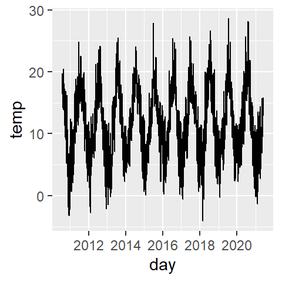

```r
ggplot(bike_weather, aes(x = day, y = temp)) +
  geom_line()
```

Try again, using `geom_point()` instead of `geom_line()`.

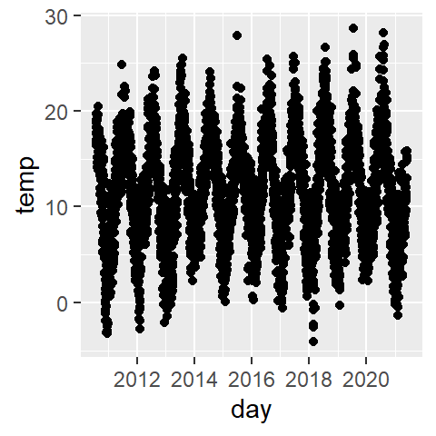

```r
ggplot(bike_weather, aes(x = day, y = temp)) +
  geom_point()
```

And now swap which column you map to x and which to y.

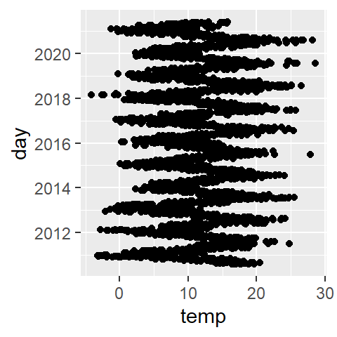

```r
ggplot(bike_weather, aes(x = temp, y = day)) +
  geom_point()
```

## Ploting distributions of `temp`

You can use other geoms to make different types of plots. For example, `geom_histogram` will make a histogram and `geom_boxplot()` will make boxplots.

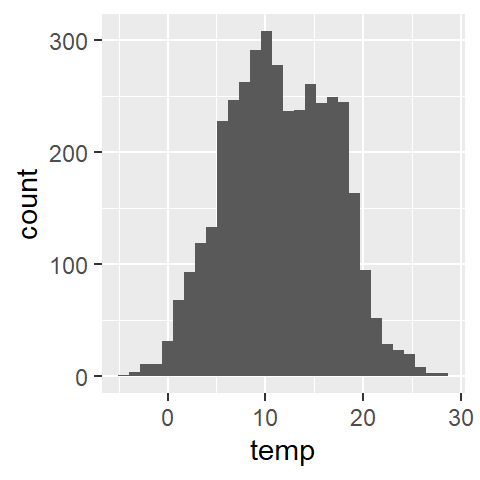

```r
ggplot(bike_weather, aes(x = temp)) +
  geom_histogram()
```

For boxplots, we frequently want categorical data on the x or y axis. For example, we might want a separate boxplot for each month. Try this out. Put `month` on the x axis, `temp` on the y axis, and use `geom_boxplot()`.

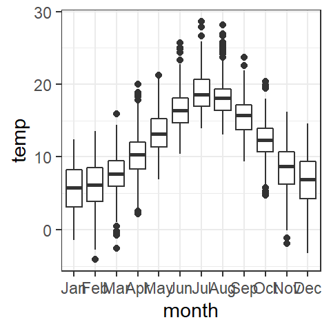

```r
ggplot(bike_weather, aes(x = month, y = temp)) +
  geom_boxplot()+
  theme_bw()
```

## Adding colour

Make a scatter plot of `temp` against `day`, using the `colour` aesthetic to colour points by month.

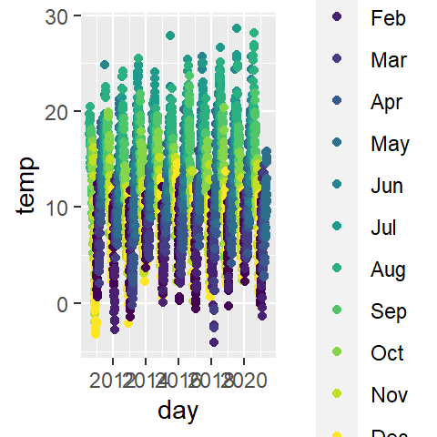

```r
ggplot(bike_weather, aes(x = day, y = temp, colour=month)) +
  geom_point()
```

## Using the `fill` aesthetic

Some geoms use a `fill` aesthetic, which is similar to `colour` but applies to shaded areas, whereas the `colour` aesthetic applies to lines and points. For example, we can use the `fill` aesthetic with `geom_boxplot()` to colour the interior of the box. Try this yourself. Plot `month` on x, `temp` on y, and colour the interior of the box by the month.

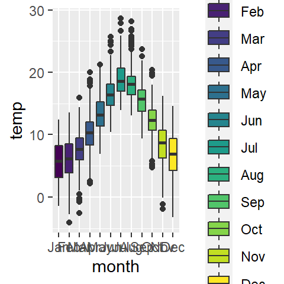

```r
ggplot(bike_weather, aes(x = month, y = temp, fill=month)) +
  geom_boxplot()
```

# Task 2: IMDB movies dataset

```r
movies <-read_csv(here::here("data","movies.csv")) %>%
    clean_names()

skimr::skim(movies)
```

Data summary

| Name | movies |
| --- | --- |
| Number of rows | 2961 |
| Number of columns | 11 |
| _______________________ |  |
| Column type frequency: |  |
| character | 3 |
| numeric | 8 |
| ________________________ |  |
| Group variables | None |

**Variable type: character**

| skim_variable | n_missing | complete_rate | min | max | empty | n_unique | whitespace |
| --- | --- | --- | --- | --- | --- | --- | --- |
| title | 0 | 1 | 1 | 83 | 0 | 2907 | 0 |
| genre | 0 | 1 | 5 | 11 | 0 | 17 | 0 |
| director | 0 | 1 | 3 | 32 | 0 | 1366 | 0 |

**Variable type: numeric**

| skim_variable | n_missing | complete_rate | mean | sd | p0 | p25 | p50 | p75 | p100 | hist |
| --- | --- | --- | --- | --- | --- | --- | --- | --- | --- | --- |
| year | 0 | 1 | 2.00e+03 | 9.95e+00 | 1920.0 | 2.00e+03 | 2.00e+03 | 2.01e+03 | 2.02e+03 | ▁▁▁▂▇ |
| duration | 0 | 1 | 1.10e+02 | 2.22e+01 | 37.0 | 9.50e+01 | 1.06e+02 | 1.19e+02 | 3.30e+02 | ▃▇▁▁▁ |
| gross | 0 | 1 | 5.81e+07 | 7.25e+07 | 703.0 | 1.23e+07 | 3.47e+07 | 7.56e+07 | 7.61e+08 | ▇▁▁▁▁ |
| budget | 0 | 1 | 4.06e+07 | 4.37e+07 | 218.0 | 1.10e+07 | 2.60e+07 | 5.50e+07 | 3.00e+08 | ▇▂▁▁▁ |
| cast_facebook_likes | 0 | 1 | 1.24e+04 | 2.05e+04 | 0.0 | 2.24e+03 | 4.60e+03 | 1.69e+04 | 6.57e+05 | ▇▁▁▁▁ |
| votes | 0 | 1 | 1.09e+05 | 1.58e+05 | 5.0 | 1.99e+04 | 5.57e+04 | 1.33e+05 | 1.69e+06 | ▇▁▁▁▁ |
| reviews | 0 | 1 | 5.03e+02 | 4.94e+02 | 2.0 | 1.99e+02 | 3.64e+02 | 6.31e+02 | 5.31e+03 | ▇▁▁▁▁ |
| rating | 0 | 1 | 6.39e+00 | 1.05e+00 | 1.6 | 5.80e+00 | 6.50e+00 | 7.10e+00 | 9.30e+00 | ▁▁▆▇▁ |

We have a look at the datafile, but let us say we wanted to explore whetther investing money in a movie is a good investment. Let us have a generate two new variables, `profit` and `return_on_budget` and have a quick look.

```r
movies %>%
  select(gross, budget) %>%
  skimr::skim()
```

Data summary

| Name | Piped data |
| --- | --- |
| Number of rows | 2961 |
| Number of columns | 2 |
| _______________________ |  |
| Column type frequency: |  |
| numeric | 2 |
| ________________________ |  |
| Group variables | None |

**Variable type: numeric**

| skim_variable | n_missing | complete_rate | mean | sd | p0 | p25 | p50 | p75 | p100 | hist |
| --- | --- | --- | --- | --- | --- | --- | --- | --- | --- | --- |
| gross | 0 | 1 | 58090401 | 72469622 | 703 | 12276810 | 34703228 | 75590286 | 7.61e+08 | ▇▁▁▁▁ |
| budget | 0 | 1 | 40619384 | 43682008 | 218 | 11000000 | 26000000 | 55000000 | 3.00e+08 | ▇▂▁▁▁ |

```r
# generate return on budget. Use mutate to create new variables
movies <- movies %>%
  mutate(profit = gross - budget,
         return_on_budget = (profit/budget)*100)
```

### Drawing numerical values as bars

For the `movies` dataset, we want to draw the `gross` amount (in USD) for each movie as a bar. Somewhat confusingly, the ggplot geometry that does this is called `geom_col()`. There is also a `geom_bar()`, but it works differently– we’ll get to that later. Make a bar plot of `gross` versus `title`. This means `gross` goes on the y axis and `title` on the x axis.

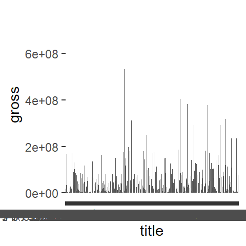

```r
ggplot(movies, aes(x = title, y = gross)) +
  geom_col()
```

Now flip which column you map onto x and which onto y.

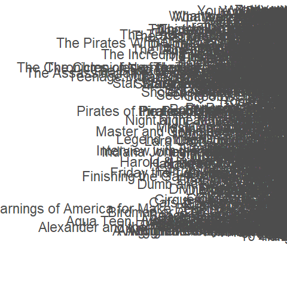

```r
ggplot(movies, aes(x = gross, y = title)) +
  geom_col()
```

- choose the top 20 movies Now these is not very useful graphs, as we have close to 3000 movies. So let us simply choose the top 20 movies using `dplyr::slice_max()` and then suing the pipe operator`%>%` , feed it into a ggplot.

```r
movies %>%
  slice_max(order_by = gross, n=20)
```

```
## # A tibble: 20 x 13
##    title    genre  director  year duration  gross budget cast_facebook_l~  votes
##    <chr>    <chr>  <chr>    <dbl>    <dbl>  <dbl>  <dbl>            <dbl>  <dbl>
##  1 Avatar   Action James C~  2009      178 7.61e8 2.37e8             4834 8.86e5
##  2 Titanic  Drama  James C~  1997      194 6.59e8 2   e8            45223 7.93e5
##  3 Jurassi~ Action Colin T~  2015      124 6.52e8 1.5 e8             8458 4.18e5
##  4 The Ave~ Action Joss Wh~  2012      173 6.23e8 2.2 e8            87697 9.95e5
##  5 The Dar~ Action Christo~  2008      152 5.33e8 1.85e8            57802 1.68e6
##  6 Star Wa~ Action George ~  1999      136 4.75e8 1.15e8            37723 5.35e5
##  7 Star Wa~ Action George ~  1977      125 4.61e8 1.1 e7            13485 9.11e5
##  8 Avenger~ Action Joss Wh~  2015      141 4.59e8 2.5 e8            92000 4.63e5
##  9 The Dar~ Action Christo~  2012      164 4.48e8 2.5 e8           106759 1.14e6
## 10 Shrek 2  Adven~ Andrew ~  2004       93 4.36e8 1.5 e8             1148 3.15e5
## 11 E.T. th~ Family Steven ~  1982      120 4.35e8 1.05e7             2811 2.82e5
## 12 The Hun~ Adven~ Francis~  2013      146 4.25e8 1.3 e8            49355 4.98e5
## 13 Pirates~ Action Gore Ve~  2006      151 4.23e8 2.25e8            48486 5.22e5
## 14 The Lio~ Adven~ Roger A~  1994       73 4.23e8 4.5 e7             6458 6.44e5
## 15 Toy Sto~ Adven~ Lee Unk~  2010      103 4.15e8 2   e8            19085 5.45e5
## 16 Iron Ma~ Action Shane B~  2013      195 4.09e8 2   e8            30426 5.57e5
## 17 The Hun~ Adven~ Gary Ro~  2012      142 4.08e8 7.8 e7            49942 7.02e5
## 18 Captain~ Action Anthony~  2016      147 4.07e8 2.5 e8            64798 2.73e5
## 19 Spider-~ Action Sam Rai~  2002      121 4.04e8 1.39e8            40484 5.45e5
## 20 Transfo~ Action Michael~  2009      150 4.02e8 2   e8             3218 3.23e5
## # ... with 4 more variables: reviews <dbl>, rating <dbl>, profit <dbl>,
## #   return_on_budget <dbl>
```

[figure not shown]

```r
movies %>%
  slice_max(order_by = gross, n=20) %>%
  ggplot(aes(x = gross, y = title)) +
  geom_col()
```

You can also change the theme to `theme_bw()` and add labels (title, subtitle, x-axis, y-axis)

[figure not shown]

```r
movies %>%
  slice_max(order_by = gross, n=20) %>%
  ggplot(aes(x = gross, y = title)) +
  geom_col()+
  theme_bw()+
  labs(
    title = "",
    subtitle = "",
    x = "Gross earnings (US$)",
    y = NULL
  )
```

### Getting bars into the right order

Whenever we are making bar plots, we need to think about the correct order of the bars. By default, ggplot uses alphabetic ordering, but it is usually best to order by the magnitude of the values, i.e., sort the bars by length.

We can do this with the `fct_reorder()` function, which takes two arguments: The categorical variable we want to re-order, and the values by which we want to order. Here, the categorical variable is the column `title` and the values are in the column `gross`. We can apply the `fct_reorder()` function right inside the `aes()` statement. fct_reorder(x,y):reorder x by y

[figure not shown]

```r
movies %>%
  slice_max(order_by = gross, n=20) %>%
  ggplot(aes(x = gross, y = fct_reorder(title, gross))) +
  geom_col() +
  theme_bw()+
  labs(
    title = "",
    subtitle = "",
    x = "Gross earnings (US$)",
    y = NULL
  )+
  NULL
```

- Colour the bars by `genre`

[figure not shown]

```r
movies %>%
  slice_max(order_by = gross, n=20) %>%
  ggplot(aes(x = gross, y = fct_reorder(title, gross),fill= genre)) +
  geom_col() +
  theme_bw()+
  labs(
    title = "",
    subtitle = "",
    x = "Gross earnings (US$)",
    y = "Movie name"
  )+
  NULL
```

- Can you make the bars blue? Inside aes, fill the variables; in geom_col, fill bars

[figure not shown]

```r
movies %>%
  slice_max(order_by = gross, n=20) %>%
  ggplot(aes(x = gross, y = fct_reorder(title, gross))) +
  geom_col(fill='blue') +
  theme_bw()+
  labs(
    title = "",
    subtitle = "",
    x = "Gross earnings (US$)",
    y = "Movie name"
  )+
  NULL
```

- Can you colour the bars by `gross` or by `title`? no
- Can you create a graph with the top/bottom 20 movies with respect to `return_on_budget`? Which were the greatest financial hits and the worst financial flops at the box office?

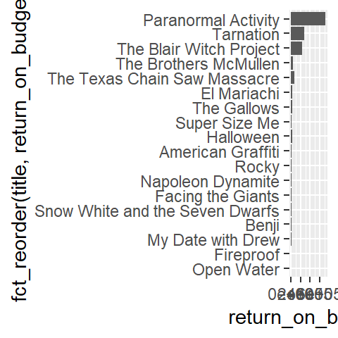

```r
movies %>%
  slice_max(order_by = return_on_budget, n=20) %>%
  ggplot(aes(x = return_on_budget, y =fct_reorder(title,return_on_budget))) +
  geom_col()
```

```r
  theme_bw()+
  labs(
    title = "",
    subtitle = "",
    x = "Return on budget",
    y = "Movie name"
  )+
  NULL
```

[output not shown]

[output cut: 368 more lines]

[output not shown]

## Reordering based on frequency

Manual reordering is cumbersome if there are many levels that need to be reorderd. Therefore, we often use functions that can reorder automatically based on some quantitative criterion. For example, we can use `fct_infreq()` to order a factor based on the number of occurrences of each level in the dataset. And we can reverse the order of a factor using the function `fct_rev()`. These two functions are particularly useful for making bar plots.

Consider the following plot of the number of movies in each genre. This plot is problematic because the genres are arranged in an arbitrary alphabetic order that is not meaningful for the data shown.

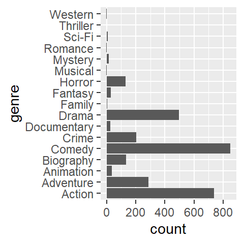

```r
movies %>%
  ggplot(aes(y = genre)) +
  geom_bar()
```

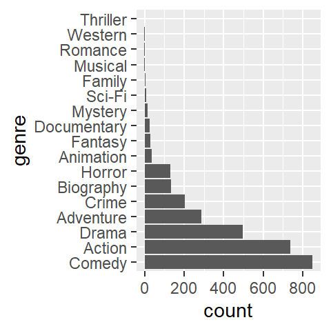

```r
movies %>%
  mutate(
    genre = fct_infreq(genre)) %>%
  ggplot(aes(y=genre))+
  geom_bar()
```

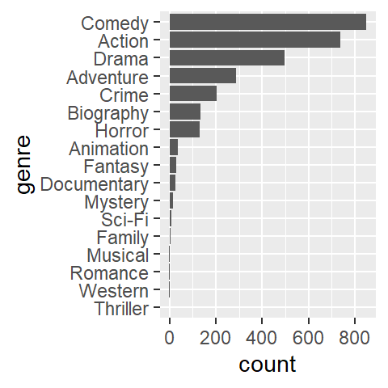

```r
movies %>%
  mutate(
    genre = fct_rev(fct_infreq(genre))) %>%
  ggplot(aes(y=genre))+
  geom_bar()
```

## Reordering based on numerical values

Another common problem we encounter is that we want to order a factor based on some other numerical variable, possibly after we have calculated some summary statistic such as the median, minimum, or maximum. As an example for this problem, we will use `gapmider` and consider a plot of life expectancy in various countries in Europe over time, shown as coloured tiles.

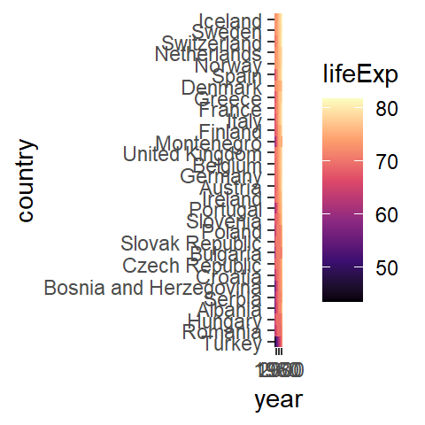

```r
gapminder %>%
  filter(continent == "Europe") %>%
  mutate(
    country = fct_reorder(country, lifeExp, median) # reorder country by median(lifeExp)
  ) %>%
  ggplot(aes(year, country, fill = lifeExp)) +
  geom_tile() + # It's the same if we use geom_col()here
  scale_fill_viridis_c(option = "A") #option here represents different fill color
```

Now, instead of plotting this data as coloured tiles, plot it as lines, using facets to make separate panels for each country.

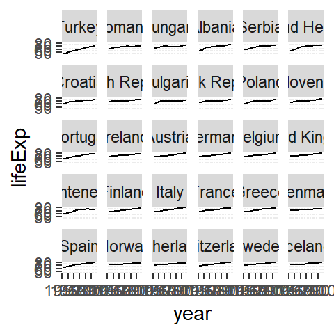

```r
gapminder %>%
  filter(continent == "Europe") %>%
  mutate(country = fct_reorder(country, lifeExp, median)) %>%
  ggplot(aes(year, lifeExp)) +
  facet_wrap(vars(country)) +
  geom_line() + NULL
```

# Task 3: NHANES (National Health and Nutrition Examination Survey)

We will look at data from NHANES, the [National Health and Nutrition Examination Survey](https://wwwn.cdc.gov/nchs/nhanes/Default.aspx)

### Data Dictionary

From the [data dictionary](http://faculty.washington.edu/kenrice/heartgraphs/):

- `BPXSAR`: systolic blood pressure (mmHg)
- `BPXDAR`: diastolic blood pressure (mmHg)
- `BPXDI1`, `BPXDI2`: two diastolic blood pressure readings
- `race_ethc`: race/ethnicity, coded as:
  - Hispanic,
  - White non-Hispanic,
  - Black non-Hispanic and
  - Other
- `gender`: sex, coded as Male/Female
- `DR1TFOLA`: folate intake (μg/day)
- `RIAGENDR`: sex, coded as 1/2
- `BMXBMI`: body mass index (kg/m2)
- `RIDAGEY`: age (years)

## Load the data set

```r
my_heart <-read_csv(here::here("data","nhaneslarge.csv")) %>%
    clean_names() %>%
  rename(
    bmi = bmxbmi,
    systolic_pressure = bpxsar,
    diastolic_pressure = bpxdar,
    folate_intake = dr1tfola,
    age = ridageyr
  ) %>%
  select(
    -c(bpxdi1,
       bpxdi2,
       riagendr
       )
  )
```

## Inspect the data set

### 1. How many rows and columns are in the `heart` data? what are the variable types? Are there are any variables which are the wrong type?

```r
# write your code
skim(my_heart)
```

Data summary

| Name | my_heart |
| --- | --- |
| Number of rows | 1000 |
| Number of columns | 7 |
| _______________________ |  |
| Column type frequency: |  |
| character | 2 |
| numeric | 5 |
| ________________________ |  |
| Group variables | None |

**Variable type: character**

| skim_variable | n_missing | complete_rate | min | max | empty | n_unique | whitespace |
| --- | --- | --- | --- | --- | --- | --- | --- |
| race_ethc | 0 | 1 | 5 | 18 | 0 | 4 | 0 |
| gender | 0 | 1 | 4 | 6 | 0 | 2 | 0 |

**Variable type: numeric**

| skim_variable | n_missing | complete_rate | mean | sd | p0 | p25 | p50 | p75 | p100 | hist |
| --- | --- | --- | --- | --- | --- | --- | --- | --- | --- | --- |
| systolic_pressure | 0 | 1.00 | 119.9 | 18.00 | 82.0 | 108.0 | 117.3 | 130.0 | 216.0 | ▃▇▂▁▁ |
| diastolic_pressure | 0 | 1.00 | 68.0 | 13.95 | 0.0 | 60.0 | 69.0 | 77.0 | 112.0 | ▁▁▆▇▁ |
| folate_intake | 0 | 1.00 | 409.3 | 242.00 | 0.0 | 250.0 | 354.0 | 492.2 | 1906.0 | ▇▅▁▁▁ |
| bmi | 9 | 0.99 | 27.1 | 6.55 | 14.2 | 22.5 | 26.6 | 30.9 | 57.4 | ▅▇▃▁▁ |
| age | 0 | 1.00 | 40.1 | 20.38 | 8.0 | 21.8 | 40.0 | 54.0 | 85.0 | ▇▆▇▅▃ |

### 2. Use `dplyr` to answer these questions:

- What is the minimum age in years?
- What is the maximum age in years?

### 3. Use `dplyr` to do the following:

- Make a new variable in `my_heart` called `age_months` that converts `age` to months.
- For individuals 280 months or older, what is the range of BMI values?

### 4. Use `ggplot2` to make a scatterplot with age in years on the x-axis and BMI on the y-axis. Colour the points by `gender`, add a best fit line using `geom_smooth()`, and add appropriate labels.

### 5. Use `dplyr` and `ggplot2` to do the following:

- Type `?case_when` to read the help documents for this `dplyr` function. Use this function to make a new variable called `age_cat` with 3 values:
  - `between(<name_of_age_var>, 0, 30)` is `age_cat == "Under 30"`
  - `between(<name_of_age_var>, 31, 55)` is `age_cat == "31-55"`
  - all other ages are `age_cat == "56+"`

You may find the attached graphic by Allison Horst useful

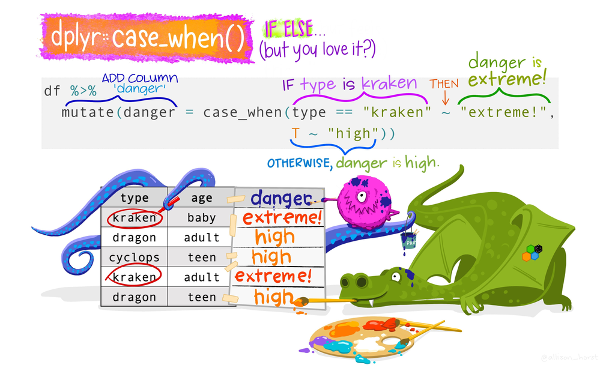

```r
my_heart <- my_heart %>%
  mutate(
    age_cat = case_when(
      age <= 30 ~ "Under 30",
      age <= 55 ~ "31-55",
      TRUE ~ "56+"
    )
  )
```

- Create a scatter plot with bmi on the x-axis and blood pressure on the y-axis, facetting by your new `age_cat` variable. Colour the points by `gender`.
- Look up `?facet_grid`, and recreate the same plot now using `gender ~ age_cat`.
- make sure the age ranges are in the correct order as, by default, R will sort the age categories alphabetically.
- use proper labelling (title, axes, caption, etc). and try `theme_bw()`

# Task 4: Our first Covid plot

## Get the data

```r
# data source: https://github.com/nytimes/covid-19-data

url <- "https://github.com/nytimes/covid-19-data/raw/master/us-states.csv"
```

Hit the play button (triangle) and look at the Environment tab. You should see a new object called `url`. Paste `url` (without the backticks) into the console and press return.

Next we’ll use `vroom::vroom()` (meaning from package `vroom`, use the `vroom()` function) to read in the `csv` data from the website. You could use `readr::read_csv()`, but `vroom` is seriously fast in reading files.

Hit play to run the chunk or put your cursor on the line and hit “Run”.

```r
nyt_covid_by_state <- vroom(url)
```

You should see the `nyt_covid_by_state` object in the Environment. Open it by expanding the blue arrow and then clicking on the object name. You’ll see a Viewer open as a new tab. Note all of the things you can do in the viewer. There are 30209 observations and 5 variables.

It’s always good practice to `glimpse` the data set to see variable types

```r
glimpse(nyt_covid_by_state)
```

```
## Rows: 30,209
## Columns: 5
## $ date   <date> 2020-01-21, 2020-01-22, 2020-01-23, 2020-01-24, 2020-01-24, 20~
## $ state  <chr> "Washington", "Washington", "Washington", "Illinois", "Washingt~
## $ fips   <chr> "53", "53", "53", "17", "53", "06", "17", "53", "04", "06", "17~
## $ cases  <dbl> 1, 1, 1, 1, 1, 1, 1, 1, 1, 2, 1, 1, 1, 2, 1, 1, 1, 2, 1, 1, 1, ~
## $ deaths <dbl> 0, 0, 0, 0, 0, 0, 0, 0, 0, 0, 0, 0, 0, 0, 0, 0, 0, 0, 0, 0, 0, ~
```

Most of them are pretty-self explanatory, with the exception of `fips`. [Federal Information Processing Standards (FIPS)](https://en.wikipedia.org/wiki/Federal_Information_Processing_Standards) code is a US federal code that numbers states and territories in the US. States are defined with two digits; e.g., NY is 36, California is 06, etc. FIPS code extends to the county level with an additional four digits, so every county in the US has a unique six-digit identifier, where the first two digits represent the state.

## The pipe %>% operator

Read from left to right, top to bottom. When you read code, think of `%>%` as **and then**.

How would we read?

```
  nyt_covid_by_state %>%
    group_by(state) %>%
    count(sort=TRUE)
```

- Start with dataframe `nyt_covid_by_state` **and then**
- group by each state **and then**
- count how many observations you have. `sort=TRUE` will put them in descending order

```
## # A tibble: 55 x 2
## # Groups:   state [55]
##    state             n
##    <chr>         <int>
##  1 Washington      591
##  2 Illinois        588
##  3 California      587
##  4 Arizona         586
##  5 Massachusetts   580
##  6 Wisconsin       576
##  7 Texas           569
##  8 Nebraska        564
##  9 Utah            556
## 10 Oregon          553
## # ... with 45 more rows
```

## Make the output a bit nicer

We can use `knitr::kable()` (which means the `kable()` function in the `{knitr}` package) and `kableExtra::kable_styling()` to format the tibble output for inclusion in our knitted file. Let us look at the first 10 rows.

```r
nyt_covid_by_state %>%
  group_by(state) %>%
  count(sort=TRUE) %>%
  head(10) %>%
  kable() %>%
  kable_styling()
```

| state | n |
| --- | --- |
| Washington | 591 |
| Illinois | 588 |
| California | 587 |
| Arizona | 586 |
| Massachusetts | 580 |
| Wisconsin | 576 |
| Texas | 569 |
| Nebraska | 564 |
| Utah | 556 |
| Oregon | 553 |

## An example of data wrangling

Even clean and tidy data files, such as this one, are rarely ready for plotting straightaway. We’ll unpack the specifics of what this code does as we move through the workshop series. For now, run the chunk.

```r
  nyt_covid_by_state %>%
    group_by(state) %>%
    mutate(daily_deaths = deaths - lag(deaths,1),
           daily_cases = cases - lag(cases,1)
           ) %>%
    filter(daily_deaths >= 3) %>%
    mutate(days = 1:n()) %>%
    mutate(label = if_else(days == max(days),
                           state,
                           NA_character_)) %>%
    ungroup() %>%
    filter(state %in% c("New York", "Florida", "California", "Texas"))
```

No output is printed because we set the chunk options to hide.

## Assign the output to an object

This time we’re going to run the same chunk but we’ll assign the output to a new object called `df_deaths`.

```r
df_deaths <- # this is a new dataframe object
  nyt_covid_by_state %>%
    group_by(state) %>%
    mutate(daily_deaths = deaths - lag(deaths,1),
           daily_cases = cases - lag(cases,1)
           ) %>%
    filter(daily_deaths >= 3) %>%
    mutate(days = 1:n()) %>%
    mutate(label = if_else(days == max(days),
                           state,
                           NA_character_)) %>%
    ungroup() %>%
    filter(state %in% c("New York", "Florida", "California", "Texas"))
```

You should see `df_deaths` in your Environment panel and you can now re-use it for later analyses.

## `ggplot()`

What happens when you just call ggplot on the dataframe, you just get an empty canvas.

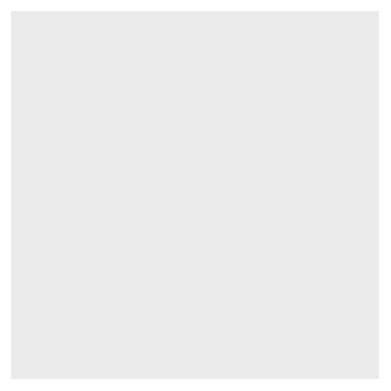

```r
# out.width='70%' makes it possible to fit the plot on the slide
  ggplot(df_deaths)
```

## Aesthetic mappings

With `aes()` we tell ggplot how our variables map onto plot features. For instance, `days` will go on the x-axis. We no longer have a completely empty canvas, but we can now see our axes. Still, we haven’t added any geometry so besides the axes and default labels for axes, we don’t have much else.

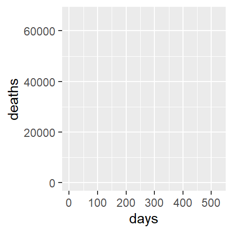

```r
  ggplot(df_deaths, aes(x=days,
                        y=deaths,
                        colour=state))
```

## Add a `geom`

Next we’ll tell `ggplot()` what type of geometric object to add– let us add lines.

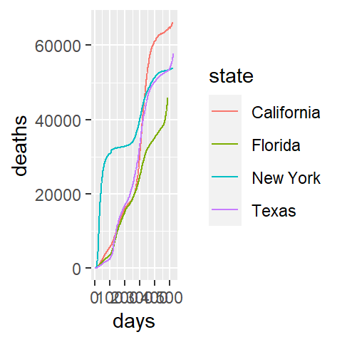

```r
  ggplot(df_deaths, aes(x=days,
                        y=deaths,
                        colour=state)) +
    geom_line()
```

Notice the order in which states appear: California, Florida, New York, Texas. Since `state` is a character variable,the default ordering is alphabetical. We will not use the legend to the right, but what if we wanted to sort states by number of deaths?

## We have more to add to our plot, but first…

We don’t have to keep repeating code over and over. We can assign what we have so far to an object, let’s call it `p`, and then add to `p`.

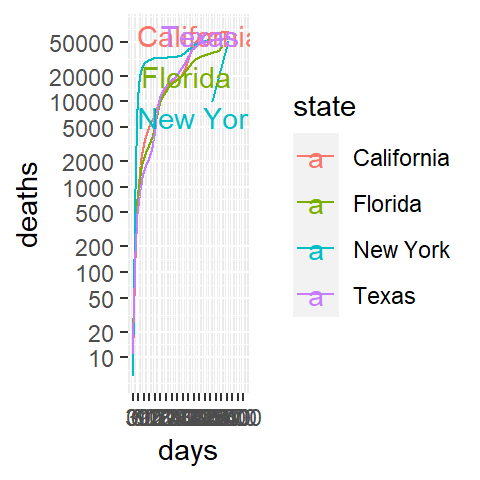

```r
p <- ggplot(df_deaths, aes(x=days,
                           y=deaths,
                           colour=state)) +
      geom_line()

p <- p +
    scale_y_log10(breaks = c(1, 10, 20, 50, 100,
                             200, 500, 1000, 2000, 5000, 10000, 20000, 50000 )) +
    scale_x_continuous(breaks = seq(0, 600, by = 30) ,
                       limits = c(1, 600)) +
    geom_text_repel(aes(label = label),
                     nudge_x = 1,
                     na.rm = TRUE)

p
```

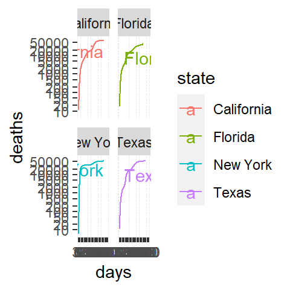

```r
# We can also use facet_wrap() to get one plot per state
p + facet_wrap(~state)
```

## Make your plots nicer

You can lose hours and days making plots perfect. Let’s use the Economist and FiveThirtyEight themes from the `ggthemes` library and. In addition, we will also use the `hrbrthemes` package and `theme_ft_rc` for a *ggplot2 theme with opinionated defaults and an emphasis on typography*.

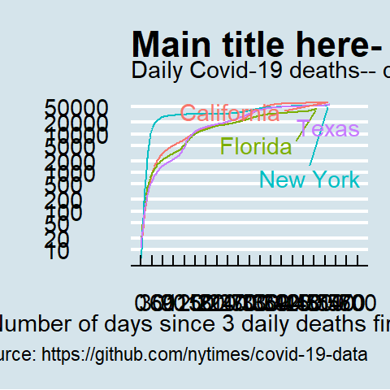

```r
p1 <- p +
    theme_economist() +
     theme(legend.position = "none",
           axis.title.x = element_text()) +
    labs(title = "Main title here- what question do you address?",
         subtitle = "Daily Covid-19 deaths-- days since 3 daily deaths first recorded",
         x = "Number of days since 3 daily deaths first recorded",
         y = "",
         caption = "Source: https://github.com/nytimes/covid-19-data")


p1
```

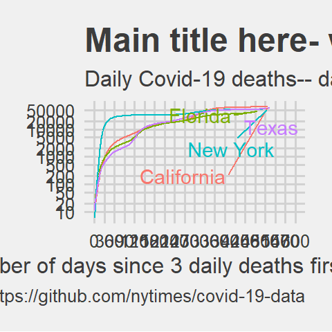

```r
p2 <- p +
    theme_fivethirtyeight() +
    theme(legend.position = "none",
          axis.title.x = element_text()) +
    labs(title = "Main title here- what question do you address?",
         subtitle = "Daily Covid-19 deaths-- days since 3 daily deaths first recorded",
         x = "Number of days since 3 daily deaths first recorded",
         y = "",
         caption = "Source: https://github.com/nytimes/covid-19-data")

p2
```

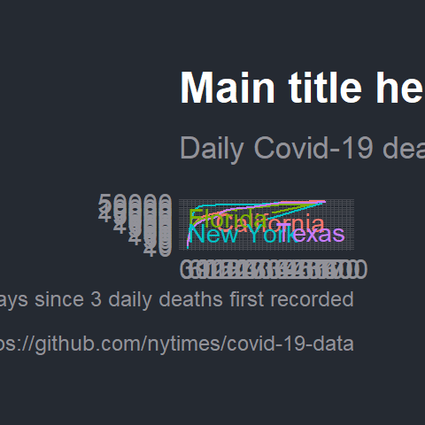

```r
p3 <-   p +
     theme_ft_rc()+
        theme(legend.position = "none",
          axis.title.x = element_text()) +
    labs(title = "Main title here- what question do you address?",
         subtitle = "Daily Covid-19 deaths-- days since 3 daily deaths first recorded",
         x = "Number of days since 3 daily deaths first recorded",
         y = "",
         caption = "Source: https://github.com/nytimes/covid-19-data")

p3
```